# BellaBeat

# How Can a Wellness Technology Company Play It Smart?

### I. Case study description:

Bellabeat is a high-tech company that manufactures health-focused smart products empowering women with knowledge about their own health and habits by collecting data on activity, sleep, stress, and reproductive health.

The Bellabeat’s founder knows that an analysis of Bellabeat’s available consumer data would reveal opportunities for growth. She has asked the marketing analytics team to focus on a Bellabeat product and analyze smart device usage data in order to gain insight into how people are already using their smart devices. Then, using this information, she would like high-level recommendations for how these trends can inform Bellabeat marketing strategy.

### II. Ask

1. Identify the business task: analyze smart device usage data in order to gain insight into how consumers use non-Bellabeat smart devices, then apply those insights to Bellabeat’s product.
2. To do the task, the analysis needs to answer these questions:
1. What are some trends in smart device usage?
2. How could these trends apply to Bellabeat customers?
3. How could these trends help influence Bellabeat marketing strategy?
3. Key stakeholders:
- Urška Sršen: Bellabeat’s cofounder and Chief Creative Officer.
- Sando Mur: Mathematician and Bellabeat’s cofounder; key member of the Bellabeat executive team.
- Bellabeat marketing analytics team: A team of data analysts responsible for collecting, analyzing, and reporting data that helps guide Bellabeat’s marketing strategy.

### III. Prepare

The data to be used in this case study is [FitBit Fitness Tracker Data](https://www.kaggle.com/datasets/arashnic/fitbit) (CC0: Public Domain, dataset made available through Mobius): This Kaggle data set contains personal fitness tracker from thirty fitbit users. Thirty eligible Fitbit users consented to the submission of personal tracker data, including minute-level output for physical activity, heart rate, and sleep monitoring. It includes information about daily activity, steps, and heart rate that can be used to explore users’ habits.

This dataset has 18 files organized in long format.

Check the dataset’s credibility:

Licensing, privacy, security, and accessibility: this dataset is under CC0: Public Domain License, means we can copy, modify, distribute and perform the work with this dataset, all without asking permission. For data privacy, this notebook applied Apache License, so I would be protected with my private data over this work.

Let’s explore if the dataset is integrity or not!

- Since exploring the dataset, I found that the dailyActivity_merged includes dailyCalories_merged; dailyIntensities_merged; dailySteps_merged. I’ve loaded those files into Excel and used Conditional Formating function to define the those files of data are consistent.
- Other problem of this dataset is that there is no meta data. Actually we need detail descriptions about every column in every file of data to understand clearly about what is the data about. Lacking of that information, there are some files that we couldn’t use since not sure about the meaning of data (minuteSleep_merged, hourlyIntensities_merged, minuteIntensitiesNarrow_merged, minuteIntensitiesWide_merged)
- Base on what we found, we note that we might have sampling bias problem and we will have a general operational approach on this case study. I pretend to analyse users’ activities till daily, so I will choose below dataset for the analysis: dailyActivity_merged: contains daily totals for steps, intensity, distance, and calories; heartrate_seconds_merged.csv; sleepDay_merged; weightLogInfo_merged. Besides, since I want to check the period that data was recorded, I will also use hourlySteps_merged for that then.

### IV. Process

1. Choosing tools: I’ll use R to clean and analyse this project.
2. Install packages:

```r
r = getOption("repos")
r["CRAN"] = "http://cran.us.r-project.org"
options(repos = r)
install.packages("tidyverse")
install.packages("janitor")
library(tidyverse)
library(janitor)
library(dplyr)
```

3. Load data:

To load data, firstly we need to get the current work directory by the function getwd(), then change the work directory (if needed) to the folder containing those data we need to load to R by the setwd() function. Then we load data using read_csv:

```r
daily_activity <- read_csv("dailyActivity_merged.csv")
hourly_step <- read_csv("hourlySteps_merged.csv")
heart_rate <- read_csv("heartrate_seconds_merged.csv")
sleep <- read_csv("sleepDay_merged.csv")
weight <- read_csv("weightLogInfo_merged.csv")
```

4. Clean data
1. Check the variable types using glimpse():

```r
glimpse(daily_activity)
```

```
## Rows: 940
## Columns: 15
## $ Id                       <dbl> 1503960366, 1503960366, 1503960366, 150396036…
## $ ActivityDate             <chr> "4/12/2016", "4/13/2016", "4/14/2016", "4/15/…
## $ TotalSteps               <dbl> 13162, 10735, 10460, 9762, 12669, 9705, 13019…
## $ TotalDistance            <dbl> 8.50, 6.97, 6.74, 6.28, 8.16, 6.48, 8.59, 9.8…
## $ TrackerDistance          <dbl> 8.50, 6.97, 6.74, 6.28, 8.16, 6.48, 8.59, 9.8…
## $ LoggedActivitiesDistance <dbl> 0, 0, 0, 0, 0, 0, 0, 0, 0, 0, 0, 0, 0, 0, 0, …
## $ VeryActiveDistance       <dbl> 1.88, 1.57, 2.44, 2.14, 2.71, 3.19, 3.25, 3.5…
## $ ModeratelyActiveDistance <dbl> 0.55, 0.69, 0.40, 1.26, 0.41, 0.78, 0.64, 1.3…
## $ LightActiveDistance      <dbl> 6.06, 4.71, 3.91, 2.83, 5.04, 2.51, 4.71, 5.0…
## $ SedentaryActiveDistance  <dbl> 0, 0, 0, 0, 0, 0, 0, 0, 0, 0, 0, 0, 0, 0, 0, …
## $ VeryActiveMinutes        <dbl> 25, 21, 30, 29, 36, 38, 42, 50, 28, 19, 66, 4…
## $ FairlyActiveMinutes      <dbl> 13, 19, 11, 34, 10, 20, 16, 31, 12, 8, 27, 21…
## $ LightlyActiveMinutes     <dbl> 328, 217, 181, 209, 221, 164, 233, 264, 205, …
## $ SedentaryMinutes         <dbl> 728, 776, 1218, 726, 773, 539, 1149, 775, 818…
## $ Calories                 <dbl> 1985, 1797, 1776, 1745, 1863, 1728, 1921, 203…
```

```r
glimpse(heart_rate)
```

```
## Rows: 2,483,658
## Columns: 3
## $ Id    <dbl> 2022484408, 2022484408, 2022484408, 2022484408, 2022484408, 2022…
## $ Time  <chr> "4/12/2016 7:21:00 AM", "4/12/2016 7:21:05 AM", "4/12/2016 7:21:…
## $ Value <dbl> 97, 102, 105, 103, 101, 95, 91, 93, 94, 93, 92, 89, 83, 61, 60, …
```

```r
glimpse(sleep)
```

```
## Rows: 413
## Columns: 5
## $ Id                 <dbl> 1503960366, 1503960366, 1503960366, 1503960366, 150…
## $ SleepDay           <chr> "4/12/2016 12:00:00 AM", "4/13/2016 12:00:00 AM", "…
## $ TotalSleepRecords  <dbl> 1, 2, 1, 2, 1, 1, 1, 1, 1, 1, 1, 1, 1, 1, 1, 1, 1, …
## $ TotalMinutesAsleep <dbl> 327, 384, 412, 340, 700, 304, 360, 325, 361, 430, 2…
## $ TotalTimeInBed     <dbl> 346, 407, 442, 367, 712, 320, 377, 364, 384, 449, 3…
```

```r
glimpse(weight)
```

```
## Rows: 67
## Columns: 8
## $ Id             <dbl> 1503960366, 1503960366, 1927972279, 2873212765, 2873212…
## $ Date           <chr> "5/2/2016 11:59:59 PM", "5/3/2016 11:59:59 PM", "4/13/2…
## $ WeightKg       <dbl> 52.6, 52.6, 133.5, 56.7, 57.3, 72.4, 72.3, 69.7, 70.3, …
## $ WeightPounds   <dbl> 115.9631, 115.9631, 294.3171, 125.0021, 126.3249, 159.6…
## $ Fat            <dbl> 22, NA, NA, NA, NA, 25, NA, NA, NA, NA, NA, NA, NA, NA,…
## $ BMI            <dbl> 22.65, 22.65, 47.54, 21.45, 21.69, 27.45, 27.38, 27.25,…
## $ IsManualReport <lgl> TRUE, TRUE, FALSE, TRUE, TRUE, TRUE, TRUE, TRUE, TRUE, …
## $ LogId          <dbl> 1.462234e+12, 1.462320e+12, 1.460510e+12, 1.461283e+12,…
```

=> To check the structure and type of variables of every dataframe.

2. To check how many users per dataframe involved to collect information from:

```r
n_distinct(daily_activity$Id)
```

```
## [1] 33
```

```r
n_distinct(heart_rate$Id)
```

```
## [1] 14
```

```r
n_distinct(sleep$Id)
```

```
## [1] 24
```

```r
n_distinct(weight$Id)
```

```
## [1] 8
```

=> Since heart_rate and weight just had 14 and 8 users Id, the sample is too small => we won’t use these 2 dataframe to analyse.

```r
rm(heart_rate)
rm(weight)
```

3. Check the names of columns of each data frame:

```r
names(daily_activity)
```

```
##  [1] "Id"                       "ActivityDate"
##  [3] "TotalSteps"               "TotalDistance"
##  [5] "TrackerDistance"          "LoggedActivitiesDistance"
##  [7] "VeryActiveDistance"       "ModeratelyActiveDistance"
##  [9] "LightActiveDistance"      "SedentaryActiveDistance"
## [11] "VeryActiveMinutes"        "FairlyActiveMinutes"
## [13] "LightlyActiveMinutes"     "SedentaryMinutes"
## [15] "Calories"
```

```r
names(sleep)
```

```
## [1] "Id"                 "SleepDay"           "TotalSleepRecords"
## [4] "TotalMinutesAsleep" "TotalTimeInBed"
```

4. Clean the columns names:

```r
daily_activity  <- clean_names(daily_activity)
sleep <- clean_names(sleep)
```

5. Change the variable types if needed:

```r
daily_activity$activity_date <- as.Date(daily_activity$activity_date, format = "%m/%d/%Y")
daily_activity$id <- as.character(daily_activity$id)
sleep <- sleep %>%
  mutate(sleep_day = as.Date(sleep_day,format ="%m/%d/%Y %I:%M:%S %p")) %>%
  mutate(id = as.character(id))
```

6. Check the duplicate rows and remove:

```r
daily_activity[duplicated(daily_activity),]
```

```
## # A tibble: 0 × 15
## # ℹ 15 variables: id <chr>, activity_date <date>, total_steps <dbl>,
## #   total_distance <dbl>, tracker_distance <dbl>,
## #   logged_activities_distance <dbl>, very_active_distance <dbl>,
## #   moderately_active_distance <dbl>, light_active_distance <dbl>,
## #   sedentary_active_distance <dbl>, very_active_minutes <dbl>,
## #   fairly_active_minutes <dbl>, lightly_active_minutes <dbl>,
## #   sedentary_minutes <dbl>, calories <dbl>
```

```r
sleep[duplicated(sleep),]
```

```
## # A tibble: 3 × 5
##   id       sleep_day  total_sleep_records total_minutes_asleep total_time_in_bed
##   <chr>    <date>                   <dbl>                <dbl>             <dbl>
## 1 4388161… 2016-05-05                   1                  471               495
## 2 4702921… 2016-05-07                   1                  520               543
## 3 8378563… 2016-04-25                   1                  388               402
```

=> We could see that just sleep data frame has 3 duplicates, we will remove those duplicates as below:

```r
sleep <- sleep %>% distinct()
```

7. Check the NULL cells:

```r
daily_activity %>%
    select() %>%
    filter(!complete.cases(.))
```

```
## # A tibble: 0 × 0
```

```r
sleep %>%
    select() %>%
    filter(!complete.cases(.))
```

```
## # A tibble: 0 × 0
```

=> We see these data frames have no NULL cells.

8. Rename the sleep_day column to activity_date:

```r
sleep <- sleep %>%
rename('activity_date' = 'sleep_day')
```

1. Merge daily_activity and sleep with the same id and activity_date:

```r
daily_activity_merge <- merge(daily_activity, sleep, all = TRUE)
```

11. Check the period of recording by using summary() for hourly_step:

```r
summary(hourly_step)
```

```
##        Id            ActivityHour         StepTotal
##  Min.   :1.504e+09   Length:22099       Min.   :    0.0
##  1st Qu.:2.320e+09   Class :character   1st Qu.:    0.0
##  Median :4.445e+09   Mode  :character   Median :   40.0
##  Mean   :4.848e+09                      Mean   :  320.2
##  3rd Qu.:6.962e+09                      3rd Qu.:  357.0
##  Max.   :8.878e+09                      Max.   :10554.0
```

The ActivityHour currently is in character data type, I would change it into timestamp format:

```r
hourly_step <- hourly_step %>% mutate(ActivityHour = strptime(ActivityHour,format ="%m/%d/%Y %I:%M:%S %p"))
```

Then, I would check its summary again:

```r
summary(hourly_step)
```

```
##        Id             ActivityHour                      StepTotal
##  Min.   :1.504e+09   Min.   :2016-04-12 00:00:00.00   Min.   :    0.0
##  1st Qu.:2.320e+09   1st Qu.:2016-04-19 01:00:00.00   1st Qu.:    0.0
##  Median :4.445e+09   Median :2016-04-26 06:00:00.00   Median :   40.0
##  Mean   :4.848e+09   Mean   :2016-04-26 11:46:42.58   Mean   :  320.2
##  3rd Qu.:6.962e+09   3rd Qu.:2016-05-03 19:00:00.00   3rd Qu.:  357.0
##  Max.   :8.878e+09   Max.   :2016-05-12 15:00:00.00   Max.   :10554.0
```

We could see the range of ActivityHour was from 2016-04-12 00:00:00.00 to 2016-05-12 15:00:00.00. We could see that the date of 2016-05-12 was not recorded fully then. So I’m going to drop rows related to that days to prevent any skew analysing.

```r
daily_activity_merge <- daily_activity_merge[daily_activity_merge$activity_date != '2016-05-12',]
```

### V. Analyze

I would create an active_minutes columns that is sum of very_active_minutes and fairly_active_minutes:

```r
daily_activity_merge  <- daily_activity_merge %>%
  group_by(activity_date) %>%
  mutate(active_minutes = very_active_minutes + fairly_active_minutes)
```

1. Summary

Check summary of the dataframe to have an overview with min, max, mean, median values of its columns:

```r
summary(daily_activity_merge)
```

```
##       id            activity_date         total_steps    total_distance
##  Length:919         Min.   :2016-04-12   Min.   :    0   Min.   : 0.000
##  Class :character   1st Qu.:2016-04-19   1st Qu.: 3959   1st Qu.: 2.680
##  Mode  :character   Median :2016-04-26   Median : 7550   Median : 5.320
##                     Mean   :2016-04-25   Mean   : 7733   Mean   : 5.559
##                     3rd Qu.:2016-05-03   3rd Qu.:10776   3rd Qu.: 7.750
##                     Max.   :2016-05-11   Max.   :36019   Max.   :28.030
##
##  tracker_distance logged_activities_distance very_active_distance
##  Min.   : 0.000   Min.   :0.0000             Min.   : 0.000
##  1st Qu.: 2.680   1st Qu.:0.0000             1st Qu.: 0.000
##  Median : 5.320   Median :0.0000             Median : 0.230
##  Mean   : 5.545   Mean   :0.1106             Mean   : 1.529
##  3rd Qu.: 7.740   3rd Qu.:0.0000             3rd Qu.: 2.115
##  Max.   :28.030   Max.   :4.9421             Max.   :21.920
##
##  moderately_active_distance light_active_distance sedentary_active_distance
##  Min.   :0.0000             Min.   : 0.000        Min.   :0.000000
##  1st Qu.:0.0000             1st Qu.: 1.985        1st Qu.:0.000000
##  Median :0.2500             Median : 3.400        Median :0.000000
##  Mean   :0.5782             Mean   : 3.372        Mean   :0.001632
##  3rd Qu.:0.8100             3rd Qu.: 4.805        3rd Qu.:0.000000
##  Max.   :6.4800             Max.   :10.710        Max.   :0.110000
##
##  very_active_minutes fairly_active_minutes lightly_active_minutes
##  Min.   :  0.00      Min.   :  0.00        Min.   :  0
##  1st Qu.:  0.00      1st Qu.:  0.00        1st Qu.:130
##  Median :  4.00      Median :  7.00        Median :200
##  Mean   : 21.55      Mean   : 13.83        Mean   :195
##  3rd Qu.: 33.00      3rd Qu.: 20.00        3rd Qu.:266
##  Max.   :210.00      Max.   :143.00        Max.   :518
##
##  sedentary_minutes    calories    total_sleep_records total_minutes_asleep
##  Min.   :   2      Min.   :   0   Min.   :1.000       Min.   : 58.0
##  1st Qu.: 732      1st Qu.:1841   1st Qu.:1.000       1st Qu.:361.0
##  Median :1065      Median :2169   Median :1.000       Median :431.5
##  Mean   : 999      Mean   :2330   Mean   :1.122       Mean   :418.7
##  3rd Qu.:1234      3rd Qu.:2799   3rd Qu.:1.000       3rd Qu.:490.0
##  Max.   :1440      Max.   :4900   Max.   :3.000       Max.   :796.0
##                                   NA's   :517         NA's   :517
##  total_time_in_bed active_minutes
##  Min.   : 61.0     Min.   :  0.00
##  1st Qu.:402.2     1st Qu.:  0.00
##  Median :462.5     Median : 21.00
##  Mean   :458.2     Mean   : 35.38
##  3rd Qu.:526.0     3rd Qu.: 58.00
##  Max.   :961.0     Max.   :275.00
##  NA's   :517
```

After take a look on summary of hourly_activity_merge, I discover some interesting points:

```r
daily_activity_merge %>% filter(total_distance == max(total_distance))
```

```
## # A tibble: 30 × 19
## # Groups:   activity_date [30]
##    id         activity_date total_steps total_distance tracker_distance
##    <chr>      <date>              <dbl>          <dbl>            <dbl>
##  1 1624580081 2016-05-01          36019           28.0             28.0
##  2 3977333714 2016-05-02          16520           11.1             11.1
##  3 4388161847 2016-05-07          22770           17.5             17.5
##  4 7007744171 2016-04-29          20067           14.3             13.4
##  5 8053475328 2016-04-13          16433           13.4             13.4
##  6 8053475328 2016-04-15          20669           16.2             16.2
##  7 8053475328 2016-04-17          18827           13.7             13.7
##  8 8053475328 2016-04-18          17076           12.7             12.7
##  9 8053475328 2016-04-23          22359           17.2             17.2
## 10 8053475328 2016-04-24          22988           18.0             18.0
## # ℹ 20 more rows
## # ℹ 14 more variables: logged_activities_distance <dbl>,
## #   very_active_distance <dbl>, moderately_active_distance <dbl>,
## #   light_active_distance <dbl>, sedentary_active_distance <dbl>,
## #   very_active_minutes <dbl>, fairly_active_minutes <dbl>,
## #   lightly_active_minutes <dbl>, sedentary_minutes <dbl>, calories <dbl>,
## #   total_sleep_records <dbl>, total_minutes_asleep <dbl>, …
```

I took the id made that record, then took another filter to see her activites:

```r
daily_activity_merge %>% filter(id == '1624580081') %>% print(n = 30)
```

```
## # A tibble: 30 × 19
## # Groups:   activity_date [30]
##    id         activity_date total_steps total_distance tracker_distance
##    <chr>      <date>              <dbl>          <dbl>            <dbl>
##  1 1624580081 2016-04-12           8163          5.31             5.31
##  2 1624580081 2016-04-13           7007          4.55             4.55
##  3 1624580081 2016-04-14           9107          5.92             5.92
##  4 1624580081 2016-04-15           1510          0.980            0.980
##  5 1624580081 2016-04-16           5370          3.49             3.49
##  6 1624580081 2016-04-17           6175          4.06             4.06
##  7 1624580081 2016-04-18          10536          7.41             7.41
##  8 1624580081 2016-04-19           2916          1.90             1.90
##  9 1624580081 2016-04-20           4974          3.23             3.23
## 10 1624580081 2016-04-21           6349          4.13             4.13
## 11 1624580081 2016-04-22           4026          2.62             2.62
```

[output cut: 26 more lines]

Then I noticed that activity was an unusual activity of this user as it was far different from her others daily activities since every day her distance recorded was around 1 to 5km, then she had 1 significant change on that day which was 28km. If this is data from my company’s system, I would ask to check if there was anything wrong.

- Maximum sedentary_minutes was 1440 minutes mean 24 hours. I would take a look to those records have sedentary_minutes equal to 1440:

```r
daily_activity_merge %>% filter(sedentary_minutes == 1440)
```

```
## # A tibble: 77 × 19
## # Groups:   activity_date [29]
##    id         activity_date total_steps total_distance tracker_distance
##    <chr>      <date>              <dbl>          <dbl>            <dbl>
##  1 1844505072 2016-04-24              0              0                0
##  2 1844505072 2016-04-25              0              0                0
##  3 1844505072 2016-04-26              0              0                0
##  4 1844505072 2016-05-02              0              0                0
##  5 1844505072 2016-05-07              0              0                0
##  6 1844505072 2016-05-08              0              0                0
##  7 1844505072 2016-05-09              0              0                0
##  8 1844505072 2016-05-10              0              0                0
##  9 1844505072 2016-05-11              0              0                0
## 10 1927972279 2016-04-16              0              0                0
## # ℹ 67 more rows
## # ℹ 14 more variables: logged_activities_distance <dbl>,
## #   very_active_distance <dbl>, moderately_active_distance <dbl>,
## #   light_active_distance <dbl>, sedentary_active_distance <dbl>,
## #   very_active_minutes <dbl>, fairly_active_minutes <dbl>,
## #   lightly_active_minutes <dbl>, sedentary_minutes <dbl>, calories <dbl>,
## #   total_sleep_records <dbl>, total_minutes_asleep <dbl>, …
```

```r
daily_activity_merge %>% filter(sedentary_minutes == 1440, total_steps != 0)
```

```
## # A tibble: 7 × 19
## # Groups:   activity_date [6]
##   id         activity_date total_steps total_distance tracker_distance
##   <chr>      <date>              <dbl>          <dbl>            <dbl>
## 1 4319703577 2016-04-12           7753           5.20             5.20
## 2 4388161847 2016-04-12          10122           7.78             7.78
## 3 8583815059 2016-04-16           5319           4.15             4.15
## 4 8583815059 2016-04-17           3008           2.35             2.35
## 5 8583815059 2016-05-02           8469           6.61             6.61
## 6 8583815059 2016-05-03          12015           9.37             9.37
## 7 8583815059 2016-05-04           3588           2.80             2.80
## # ℹ 14 more variables: logged_activities_distance <dbl>,
## #   very_active_distance <dbl>, moderately_active_distance <dbl>,
## #   light_active_distance <dbl>, sedentary_active_distance <dbl>,
## #   very_active_minutes <dbl>, fairly_active_minutes <dbl>,
## #   lightly_active_minutes <dbl>, sedentary_minutes <dbl>, calories <dbl>,
## #   total_sleep_records <dbl>, total_minutes_asleep <dbl>,
## #   total_time_in_bed <dbl>, active_minutes <dbl>
```

There were 7 observations that have sedentary_minutes = 1440 and total_step significantly >0. Those observations are quite confusing as it makes no sense that 1 person walk 10000 steps and be considered as sedentary for the whole day. In this case, as the number of records is not significant for the dataset, I’m going to still keep those record for the analysis, besides, I will recommend to the data team to check our own data frequently to avoid those confusing records. - The 3rd quartile of logged_activities_distance is 0km, so 75% records of this attribute is 0km, I would want to know exactly how many records have the logged_activities_distance is not 0km.

```r
daily_activity_merge %>% filter(logged_activities_distance !=0)
```

```
## # A tibble: 32 × 19
## # Groups:   activity_date [19]
##    id         activity_date total_steps total_distance tracker_distance
##    <chr>      <date>              <dbl>          <dbl>            <dbl>
##  1 6775888955 2016-04-26           7091           5.27             5.27
##  2 6962181067 2016-04-21          11835           9.71             7.88
##  3 6962181067 2016-04-25          13239           9.27             9.08
##  4 6962181067 2016-05-09          12342           8.72             8.68
##  5 7007744171 2016-04-12          14172          10.3              9.48
##  6 7007744171 2016-04-13          12862           9.65             8.60
##  7 7007744171 2016-04-14          11179           8.24             7.48
##  8 7007744171 2016-04-18          14816          11.0              9.91
##  9 7007744171 2016-04-19          14194          10.5              9.5
## 10 7007744171 2016-04-20          15566          11.3             10.4
## # ℹ 22 more rows
## # ℹ 14 more variables: logged_activities_distance <dbl>,
## #   very_active_distance <dbl>, moderately_active_distance <dbl>,
## #   light_active_distance <dbl>, sedentary_active_distance <dbl>,
## #   very_active_minutes <dbl>, fairly_active_minutes <dbl>,
## #   lightly_active_minutes <dbl>, sedentary_minutes <dbl>, calories <dbl>,
## #   total_sleep_records <dbl>, total_minutes_asleep <dbl>, …
```

The result shows that just 32/919 ~ 3.5% records have the logged_activities_distance is not 0km, means that almost activities records are from the auto track mode of the tracker.

Besides, 24/33 users recorded their sleep, and:

```r
daily_activity_merge %>%
  drop_na() %>%
  group_by(id) %>%
  summarize(count_records = n_distinct(activity_date)) %>%
  arrange(count_records) %>%
  print(n=24)
```

```
## # A tibble: 24 × 2
##    id         count_records
##    <chr>              <int>
##  1 2320127002             1
##  2 7007744171             2
##  3 1844505072             3
##  4 6775888955             3
##  5 8053475328             3
##  6 1644430081             4
##  7 1927972279             5
##  8 4558609924             5
##  9 4020332650             8
## 10 2347167796            15
## 11 8792009665            15
## 12 6117666160            18
## 13 4388161847            23
## 14 7086361926            23
## 15 1503960366            25
## 16 4319703577            25
## 17 4702921684            26
## 18 5577150313            26
## 19 2026352035            27
## 20 4445114986            27
## 21 3977333714            28
## 22 5553957443            30
## 23 6962181067            30
## 24 8378563200            30
```

2. How active are the users?

I would categorize users by their active level (considering to their mean calories burned per day) to see the trend of users’ activity: - Sedentary: less than 1800 calories per day - Moderately active: ranging from 1,800 to 2,400 calories per day. - Active: more than 2400 calories per day.

```r
user_type <- daily_activity_merge %>%
  group_by(id) %>%
  summarise(mean_calories = mean(calories)) %>%
  mutate(user_type = case_when(
    mean_calories < 1800 ~ "sedentary",
    mean_calories >= 1800 & mean_calories <= 2400 ~ "moderately active",
    mean_calories > 2400 ~ "active")) %>%
  group_by(user_type) %>%
  summarise(percentage = n()/nrow(.)) %>%
  mutate(labels = scales::percent(percentage))
```

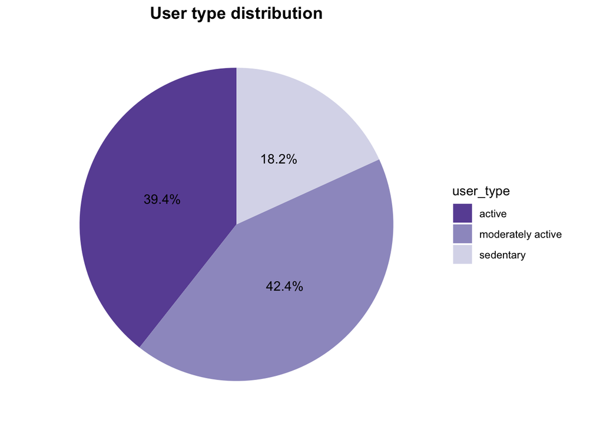

```r
user_type %>%
  ggplot(aes(x="", y=percentage, fill=user_type)) +
  geom_bar(stat = "identity", width = 1) +
  coord_polar("y", start=0) +
  theme_minimal() +
  theme(axis.title.x= element_blank(),
        axis.title.y = element_blank(),
        panel.border = element_blank(),
        panel.grid = element_blank(),
        axis.ticks = element_blank(),
        axis.text.x = element_blank(),
        plot.title = element_text(hjust = 0.5, size=14, face = "bold")) +
  scale_fill_manual(values = c("#6A51A3","#9E9AC8", "#DADAEB")) +
  geom_text(aes(label = labels),
            position = position_stack(vjust = 0.5)) +
  labs(title="User type distribution")
```

Let’s further take a look on the mean steps users took during the period:

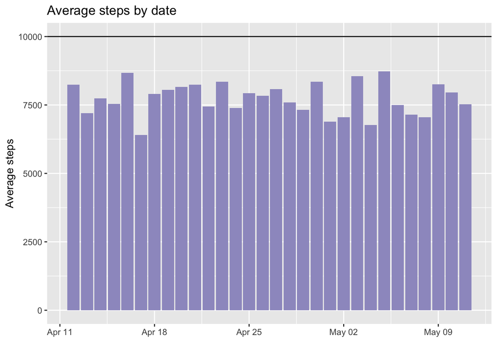

```r
daily_activity_merge %>%
  group_by(activity_date) %>%
  summarize(mean_steps = mean(total_steps)) %>%
  ggplot(mapping = aes(x = activity_date, y = mean_steps)) +
  geom_col(fill = "#9e9ac8") +
  geom_hline(yintercept = 10000) +
  labs(x = " ", y = "Average steps", title = "Average steps by date")
```

3. How is users’ sleep?

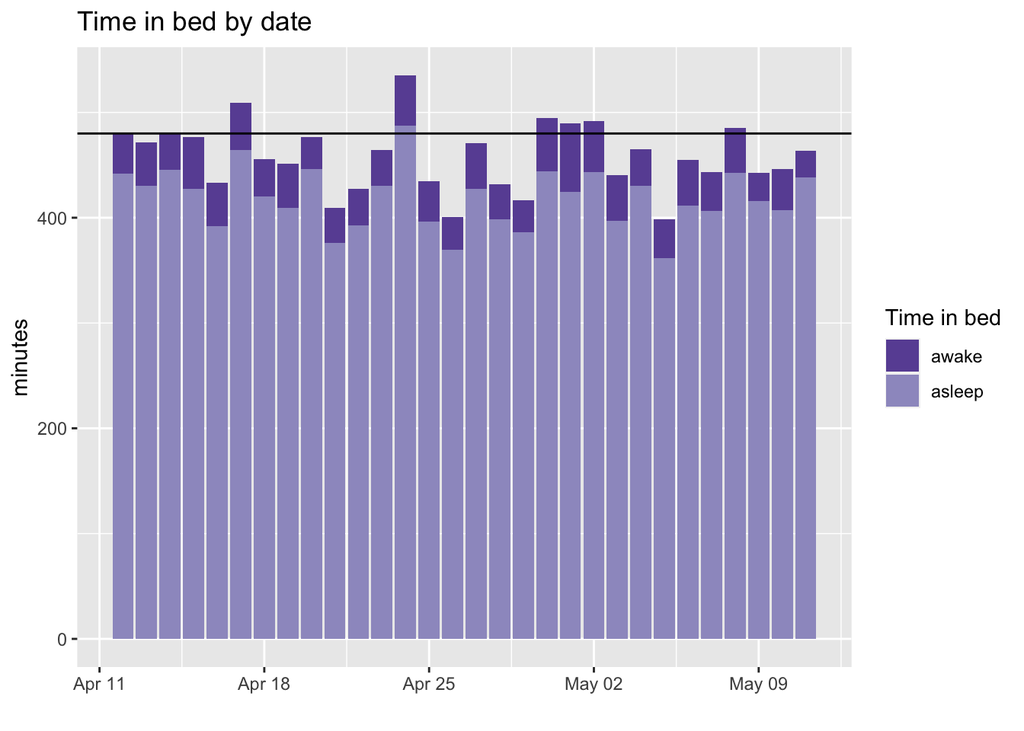

```r
daily_activity_merge %>%
  drop_na() %>%
  mutate(awake_in_bed = total_time_in_bed - total_minutes_asleep) %>%
  group_by(activity_date) %>%
  summarise(asleep = mean(total_minutes_asleep), awake = mean(awake_in_bed)) %>%
  pivot_longer(cols = c("awake", "asleep"), names_to = "time_in_bed", values_to = "minutes") %>%
  select(activity_date, time_in_bed, minutes) %>%
  ggplot(aes(x = activity_date, y = minutes, fill = factor(time_in_bed, levels = c("awake", "asleep")))) +
    geom_col() +
    geom_hline(yintercept = 480) +
    scale_fill_manual(values = c("#6A51A3", "#9E9AC8")) +
    labs(title = "Time in bed by date", x = " ", fill = "Time in bed")
```

We could see that users’ time in bed varied. Although the total time in bed seems sometime getting the recommendation sleep time of 8 hours (480 mins), the actual asleep time almost lower much lower than that. This shows users don’t have a stable routine for their sleep and their sleep aren’t healthy enough.

4. Sedentary life style

According to the summary of daily_activity_merge, the average number of sedentary minutes per day is 999 mins (>16 hours and 30 minutes), 25% records have the number of sedentary minutes from and higher than 1234 mins (> 20 hours and 30 minutes); section 2 also shows that almost 20% users are considered sedentary. As various health organizations and experts emphasize the importance of reducing sedentary behavior and incorporating regular movement throughout the day for better overall health. Marketing team could bold health risks of sedentary lifestyle with some solutions and link to how our tracker could help them aware of, control and improve their health through reducing sedentary activities.

### VI. Recommendation

1. As we see within the small and poor dataset, this shows clearly that users are not willing to share the whole or a part of their health/daily activity to others. This seems obvious but we could emphasize our policy of keeping customers’ data private and tell about our feature of deactive the app (as well as delete the data) on whatever devices the customers want to show how we care about customers’ data privacy.
2. As almost users didn’t log their activities regularly, the marketing team has the opportunity to underscore the device’s attributes of being lightweight, wearable, and self-operating. This way, users can comfortably wear the device throughout the day, enabling continuous 24/7 tracking without requiring any additional interventions.
3. Given that a substantial portion of users acknowledges the significance of exercise, yet their engagement appears to lack consistency, an effective strategy to enhance their motivation and commitment to workouts could involve establishing individualized goals, implementing incentive-based rewards, and fostering a sense of community within the exercise realm.
4. Given the suboptimal quality of users’ sleep, the marketing team has the potential to accentuate the profound impact of restful sleep on overall well-being. This approach could highlight how a tracker can assist in monitoring both sleep patterns and overall health, thereby underscoring the device’s value.
5. With health organizations and experts underscoring the significance of diminishing sedentary habits and integrating consistent physical activity into daily routines to enhance overall well-being, the marketing team possesses an opportunity to highlight the health hazards associated with a sedentary lifestyle. By presenting viable solutions, they can illustrate how our tracker aids in raising awareness about these risks, enabling users to manage and enhance their health by curtailing sedentary behaviors.